# Lake valuation visualization

Aayush Agrawal

December 14, 2016

The explanation shows how we can set up R with SQL server for our analysis -

## Make a connection locally using ODBC

### Step 1 Once the import is done we need to connect it with SQL server. But before than we need to set a odbc connection -

[figure not shown]

### Step 2 Go to system dsn tab and click on “ADD” -

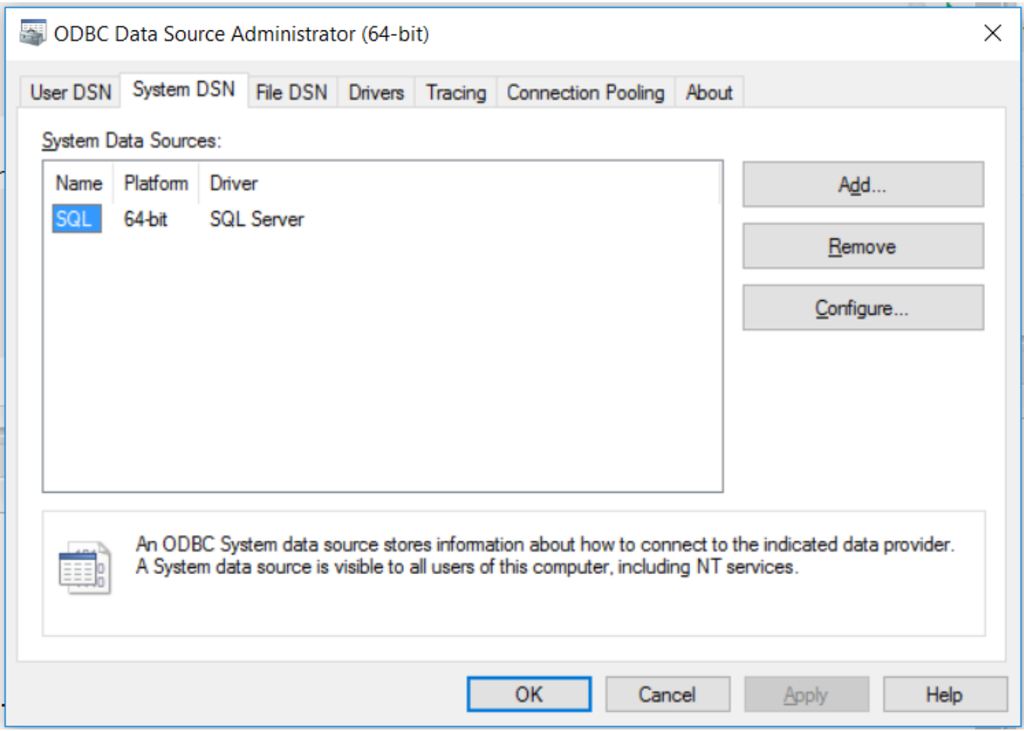

### Step 3: Click on SQL server and click Finish. -

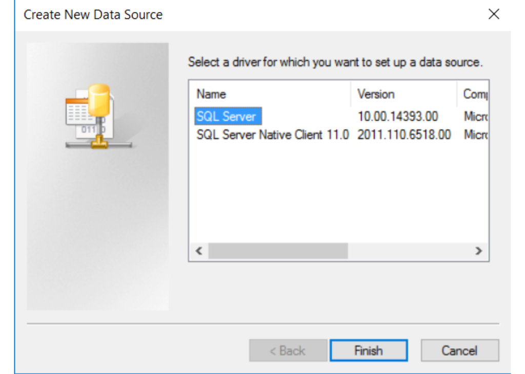

### Step 4: This will open a new wizard type name as name you want to refer to and SQLserver like “msba.csom.****”"

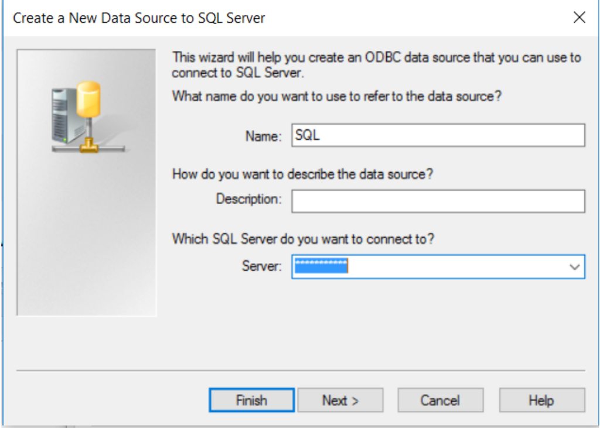

### Step 5: Select the second option of SQL server with user name and password. Type in your username and password.

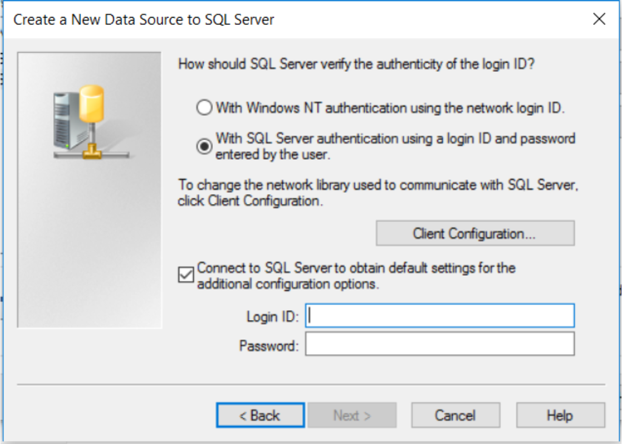

### Step 6: Then click next -> next -> next until finish.

## Analysis

Lets start by importing some file

```r
####### Importing Required libraries ########
library(RODBC)
```

```r
library(ggplot2)
```

Now making a SQL connection -

```r
####### Making SQL Server connection ########
channel <- odbcConnect("SQL", uid="{your user name}", pwd="{your password}", believeNRows=FALSE)
odbcGetInfo(channel)
```

Pulling data from the dabase -

```r
###### Pulling data #######
average_valueation <- sqlQuery(channel,"
                 SELECT a.Dist_bin, ROUND(AVG(a.ValuePerAcre),0) AS ValuePerAcre
FROM (
                           SELECT lakeID,
                           ROUND (Distance/1000,0) AS Dist_bin,
                           IIF (SUM(ParcelSize) = 0,0,SUM(emvTotal) / SUM(ParcelSize)) ValuePerAcre
                           FROM dbo.fact_water
                           GROUP BY lakeid, ROUND(Distance/1000,0)) AS a
                           GROUP BY a.Dist_bin

                           ;")
```

Making some manipulations.

```r
# Adding 1 to distance bin
average_valueation$Dist_bin <- average_valueation$Dist_bin + 1

# Filtering out bins with valuation as zero
average_valueation <- average_valueation[average_valueation$ValuePerAcre > 0,]

# Converting bin from numeric to factor
average_valueation$Dist_bin <- as.factor(average_valueation$Dist_bin)

# Calculating Correlation
correlation_value <- round(cor(as.numeric(average_valueation$Dist_bin),average_valueation$ValuePerAcre),2)
```

Let’s visualize the property valuation by lake distance -

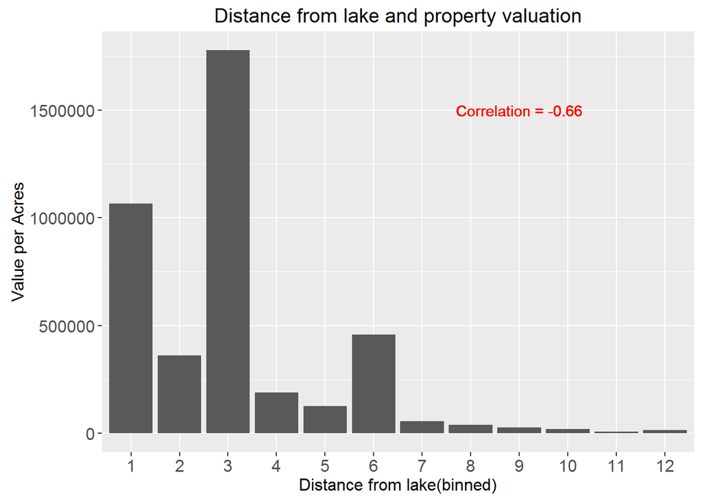

```r
###### Visualization ########
ggplot(average_valueation, aes(x=Dist_bin, y=ValuePerAcre)) + geom_bar(stat = "identity") + labs(title=paste("Distance from lake and property valuation"), x="Distance from lake(binned)", y="Value per Acres") + geom_text(x=9, y=1500000, label=paste("Correlation =",correlation_value),color = "red") +theme(text = element_text(size=12),axis.text = element_text(size=12))
```

As we can see Property valuation decreases with increase in Lake distance. The correlation b/w distance bins of 1000 meters and average valuation per acre is around -0.66.